# Clase 02

```
Tibles, filtrar y agrupar:
dplyr, filter, arrange, select, mutate,
summarise, group_by, ungroup,
```

Una versión actualizada de este material en : [clase02](https://mar71n.github.io/rconr/clase02.html)

```r
#install.packages("dplyr")
library(dplyr)
#install.packages("readr")
library(readr)
#install.packages("lubridate")
library(lubridate)
```

### Datasets

#### Tomamos de data.buenosaires el registro de vacunaciones:

```r
# https://data.buenosaires.gob.ar/dataset/plan-de-vacunacion-covid-19
#vacunas <- read_csv("https://cdn.buenosaires.gob.ar/datosabiertos/datasets/salud/plan-de-vacunacion-covid-19/dataset_total_vacunas.csv")
# download.file("https://cdn.buenosaires.gob.ar/datosabiertos/datasets/salud/plan-de-vacunacion-covid-19/dataset_total_vacunas.csv", "datos/dataset_total_vacunas.csv")
vacunas <- read_csv("datos/dataset_total_vacunas.csv")
```

#### Una primera mirada, según lo que esperemos, por lo general alguno de estos:

#### [readr::spec](https://readr.tidyverse.org/reference/spec.html)

```r
spec(vacunas)
head(vacunas)
```

```
## # A tibble: 6 × 9
##   FECHA_ADMINISTRACION GRUPO_ETARIO GENERO VACUNA  TIPO_EFECTOR  DOSIS_1 DOSIS_2
##   <chr>                <chr>        <chr>  <chr>   <chr>           <dbl>   <dbl>
## 1 03FEB2021:00:00:00   61 a 70      M      Sputnik Público           239       2
## 2 03FEB2021:00:00:00   61 a 70      M      Sputnik Público naci…      13       0
## 3 03FEB2021:00:00:00   71 a 80      F      Sputnik Público            28       0
## 4 03FEB2021:00:00:00   71 a 80      M      Sputnik Privado             5       0
## 5 03FEB2021:00:00:00   71 a 80      M      Sputnik Público            31       0
## 6 03FEB2021:00:00:00   81 a 90      F      Sputnik Público             2       0
## # … with 2 more variables: ID_CARGA <lgl>, DOSIS_3 <dbl>
```

```r
summary(vacunas)
```

```
##  FECHA_ADMINISTRACION GRUPO_ETARIO          GENERO             VACUNA
##  Length:35384         Length:35384       Length:35384       Length:35384
##  Class :character     Class :character   Class :character   Class :character
##  Mode  :character     Mode  :character   Mode  :character   Mode  :character
##
##
##
##
##  TIPO_EFECTOR          DOSIS_1            DOSIS_2         ID_CARGA
##  Length:35384       Min.   :    0.00   Min.   :    0.00   Mode:logical
##  Class :character   1st Qu.:    0.00   1st Qu.:    0.00   NA's:35384
##  Mode  :character   Median :    1.00   Median :    2.00
##                     Mean   :   81.76   Mean   :   78.43
##                     3rd Qu.:   12.00   3rd Qu.:   15.00
##                     Max.   :16520.00   Max.   :14547.00
##
##     DOSIS_3
##  Min.   :   0.00
##  1st Qu.:   0.00
##  Median :   0.00
##  Mean   :  58.56
##  3rd Qu.:   3.00
##  Max.   :7694.00
##  NA's   :83
```

##### veo que en DOSIS_3 hay NAs

#### filtro los que tienen NAs

#### con [*[*](https://www.rdocumentation.org/packages/base/versions/3.6.2/topics/Extract)

```r
vacunas[is.na(vacunas$DOSIS_3),c(-1,-8)]
```

```
## # A tibble: 83 × 7
##    GRUPO_ETARIO GENERO VACUNA      TIPO_EFECTOR     DOSIS_1 DOSIS_2 DOSIS_3
##    <chr>        <chr>  <chr>       <chr>              <dbl>   <dbl>   <dbl>
##  1 61 a 70      M      Sputnik     Público                1       0      NA
##  2 51 a 60      M      AstraZeneca Privado                2       0      NA
##  3 91 o mas     M      AstraZeneca Privado                1       0      NA
##  4 51 a 60      M      AstraZeneca Privado                0       1      NA
##  5 30 o menos   F      AstraZeneca Público                1       0      NA
##  6 71 a 80      F      AstraZeneca Público                1       0      NA
##  7 31 a 40      F      AstraZeneca Público                0       1      NA
##  8 71 a 80      F      AstraZeneca Privado                1       0      NA
##  9 41 a 50      F      Sputnik     Público nacional       0       1      NA
## 10 61 a 70      F      Sinopharm   Público                1       0      NA
## # … with 73 more rows
```

#### o con [*dplyr::filter*](https://dplyr.tidyverse.org/reference/filter.html)

##### Subconjunto de datos donde todas las condiciones son VERDADERAS.

- ```r
  x <- tribble(
    ~A, ~B, ~C,
    #--|--|---
    "a", "t", 1,
    "a", "b", 1,
    "b", "u", 2,
    "c", NA, 3,
    "c", "b", 3
  )

  x
  ```

  ```
  ## # A tibble: 5 × 3
  ##   A     B         C
  ##   <chr> <chr> <dbl>
  ## 1 a     t         1
  ## 2 a     b         1
  ## 3 b     u         2
  ## 4 c     <NA>      3
  ## 5 c     b         3
  ```

  ```r
  # Las dos condiciones son VERDADERAS
  x %>% filter(A == "a", B == "b")
  ```

  ```
  ## # A tibble: 1 × 3
  ##   A     B         C
  ##   <chr> <chr> <dbl>
  ## 1 a     b         1
  ```

  ```r
  # Equivalente a & (AND) con [
  x[x$A == "a" & x$B == "b",]
  ```

  ```
  ## # A tibble: 1 × 3
  ##   A     B         C
  ##   <chr> <chr> <dbl>
  ## 1 a     b         1
  ```

  ```r
  # Si la condicion es NA, el registro es excluido por filter (cosa esperable), pero no por [
  x$B == "t"
  ```

  ```
  ## [1]  TRUE FALSE FALSE    NA FALSE
  ```

  ```r
  x %>% filter(B == "t")
  ```

  ```
  ## # A tibble: 1 × 3
  ##   A     B         C
  ##   <chr> <chr> <dbl>
  ## 1 a     t         1
  ```

  ```r
  x[x$B == "t",]
  ```

  ```
  ## # A tibble: 2 × 3
  ##   A     B         C
  ##   <chr> <chr> <dbl>
  ## 1 a     t         1
  ## 2 <NA>  <NA>     NA
  ```

#### Podemos usar para construir las condiciones:

##### ==, >, <, >= …

##### &, |, !, xor()

##### is.na()

##### between(), near()

```r
vacunas %>% filter(is.na(vacunas$DOSIS_3)) %>% select(-FECHA_ADMINISTRACION, -ID_CARGA)
```

```
## # A tibble: 83 × 7
##    GRUPO_ETARIO GENERO VACUNA      TIPO_EFECTOR     DOSIS_1 DOSIS_2 DOSIS_3
##    <chr>        <chr>  <chr>       <chr>              <dbl>   <dbl>   <dbl>
##  1 61 a 70      M      Sputnik     Público                1       0      NA
##  2 51 a 60      M      AstraZeneca Privado                2       0      NA
##  3 91 o mas     M      AstraZeneca Privado                1       0      NA
##  4 51 a 60      M      AstraZeneca Privado                0       1      NA
##  5 30 o menos   F      AstraZeneca Público                1       0      NA
##  6 71 a 80      F      AstraZeneca Público                1       0      NA
##  7 31 a 40      F      AstraZeneca Público                0       1      NA
##  8 71 a 80      F      AstraZeneca Privado                1       0      NA
##  9 41 a 50      F      Sputnik     Público nacional       0       1      NA
## 10 61 a 70      F      Sinopharm   Público                1       0      NA
## # … with 73 more rows
```

#### pongo cero en esos NAs

```r
vacunas[is.na(vacunas$DOSIS_3), "DOSIS_3"] <- 0

summary(vacunas)
```

```
##  FECHA_ADMINISTRACION GRUPO_ETARIO          GENERO             VACUNA
##  Length:35384         Length:35384       Length:35384       Length:35384
##  Class :character     Class :character   Class :character   Class :character
##  Mode  :character     Mode  :character   Mode  :character   Mode  :character
##
##
##
##  TIPO_EFECTOR          DOSIS_1            DOSIS_2         ID_CARGA
##  Length:35384       Min.   :    0.00   Min.   :    0.00   Mode:logical
##  Class :character   1st Qu.:    0.00   1st Qu.:    0.00   NA's:35384
##  Mode  :character   Median :    1.00   Median :    2.00
##                     Mean   :   81.76   Mean   :   78.43
##                     3rd Qu.:   12.00   3rd Qu.:   15.00
##                     Max.   :16520.00   Max.   :14547.00
##     DOSIS_3
##  Min.   :   0.00
##  1st Qu.:   0.00
##  Median :   0.00
##  Mean   :  58.42
##  3rd Qu.:   3.00
##  Max.   :7694.00
```

#### Frecuencias

##### Con [*base::table*](https://www.rdocumentation.org/packages/base/versions/3.6.2/topics/table)

```r
table(vacunas$GENERO)
```

```
##
##     F     M     N
## 18323 17034    27
```

```r
table(vacunas$GRUPO_ETARIO)
```

```
##
## 30 o menos    31 a 40    41 a 50    51 a 60    61 a 70    71 a 80    81 a 90
##       5579       4995       4853       4799       4582       4232       3598
##   91 o mas
##       2746
```

#### Al modo dplyr:

- [summarise](https://dplyr.tidyverse.org/reference/summarise.html) Resume cada grupo en menos filas.

  El resultado es una (o más) filas para cada combinación de variables de agrupación; si no hay variables de agrupación, la salida tendrá una sola fila que resuma todas las observaciones en la entrada. Contendrá una columna para cada variable de agrupación y una columna para cada una de las estadísticas de resumen que haya especificado. summarise() y summarize() son sinónimos.
- Funciones útiles
  - Centro: mean(), median()
  - Dispersión: sd(), IQR(), mad()
  - Rango: min(), max(), quantile()
  - Posición: first(), last(), nth()
  - Cuenta: n(), n_distinct()
  - Lógico: any(), all()

  ```r
  vacunas %>% summarise(mean(DOSIS_1))
  ```

  ```
  ## # A tibble: 1 × 1
  ##   `mean(DOSIS_1)`
  ##             <dbl>
  ## 1            81.8
  ```

- [group_by](https://dplyr.tidyverse.org/reference/group_by.html)

  group_by() toma un tbl existente y lo convierte en un tbl agrupado donde las operaciones se realizan “por grupo”. ungroup() elimina la agrupación.

  ```r
  vacunas %>% group_by(GENERO) %>% summarise(mean(DOSIS_1))
  ```

  ```
  ## # A tibble: 3 × 2
  ##   GENERO `mean(DOSIS_1)`
  ##   <chr>            <dbl>
  ## 1 F               84.6
  ## 2 M               78.8
  ## 3 N                0.519
  ```

- [count](https://dplyr.tidyverse.org/reference/count.html)

  *count()* le permite contar rápidamente los valores únicos de una o más variables: **df %>% count(a, b)** es aproximadamente *equivalente* a **df %>% group_by(a, b) %>% summarise(n = n() )**. *count()* está emparejado con tally(), un asistente de nivel inferior que es equivalente a df %>% summarise(n = n()).

  Pasamos un **wt** para ponderar, cambiando el resumen de n = n() a n = sum(wt).

  ```r
  vacunas %>% count(GENERO)
  ```

  ```
  ## # A tibble: 3 × 2
  ##   GENERO     n
  ##   <chr>  <int>
  ## 1 F      18323
  ## 2 M      17034
  ## 3 N         27
  ```

  ```r
  vacunas %>% group_by(GENERO) %>% summarise(total = n())
  ```

  ```
  ## # A tibble: 3 × 2
  ##   GENERO total
  ##   <chr>  <int>
  ## 1 F      18323
  ## 2 M      17034
  ## 3 N         27
  ```

  ```r
  vacunas %>% count(GENERO, wt = DOSIS_1)
  ```

  ```
  ## # A tibble: 3 × 2
  ##   GENERO       n
  ##   <chr>    <dbl>
  ## 1 F      1549893
  ## 2 M      1343043
  ## 3 N           14
  ```

  ```r
  vacunas %>% group_by(GENERO) %>% summarise(total = sum(DOSIS_1))
  ```

  ```
  ## # A tibble: 3 × 2
  ##   GENERO   total
  ##   <chr>    <dbl>
  ## 1 F      1549893
  ## 2 M      1343043
  ## 3 N           14
  ```

  ```r
  vacunas %>% count(VACUNA, wt = DOSIS_1)
  ```

  ```
  ## # A tibble: 7 × 2
  ##   VACUNA                                                                    n
  ##   <chr>                                                                 <dbl>
  ## 1 AstraZeneca                                                          753360
  ## 2 Moderna                                                               26898
  ## 3 Sinopharm                                                           1000094
  ## 4 Sputnik                                                              887822
  ## 5 vacuna Coronavirus (CANSINO), vial x 1 dosis                          29431
  ## 6 vacuna Coronavirus (PFIZER) 1ra - 2da dosis, vial x 6 dosis (0.3ml)  193132
  ## 7 vacuna Coronavirus (PFIZER) pediátrica, vial x 10 dosis (0.2ml)        2213
  ```

#### Que pasa con las fechas ?

##### Para esto cargamos la libreria [*lubridate*](https://lubridate.tidyverse.org/)

```r
head(vacunas$FECHA_ADMINISTRACION)
```

```
## [1] "03FEB2021:00:00:00" "03FEB2021:00:00:00" "03FEB2021:00:00:00"
## [4] "03FEB2021:00:00:00" "03FEB2021:00:00:00" "03FEB2021:00:00:00"
```

```r
max(vacunas$FECHA_ADMINISTRACION)
```

```
## [1] "31OCT2021:00:00:00"
```

```r
dmy_hms(head(vacunas$FECHA_ADMINISTRACION))
```

```
## [1] "2021-02-03 UTC" "2021-02-03 UTC" "2021-02-03 UTC" "2021-02-03 UTC"
## [5] "2021-02-03 UTC" "2021-02-03 UTC"
```

```r
max(dmy_hms(vacunas$FECHA_ADMINISTRACION))
```

```
## [1] "2022-06-15 UTC"
```

#### Seleccionar columnas de interes, agregar columnas

##### *select()* y

##### [mutate()](https://dplyr.tidyverse.org/reference/mutate.html)

##### Crear, modificar y eliminar columnas.

##### **mutate()** agrega nuevas variables y conserva las existentes; **transmute()** agrega nuevas variables y elimina las existentes. Las nuevas variables sobrescriben las variables existentes del mismo nombre. Las variables se pueden eliminar estableciendo su valor en NULL

```r
vacunas %>% select(GENERO, GRUPO_ETARIO)
```

```
## # A tibble: 35,384 × 2
##    GENERO GRUPO_ETARIO
##    <chr>  <chr>
##  1 M      61 a 70
##  2 M      61 a 70
##  3 F      71 a 80
##  4 M      71 a 80
##  5 M      71 a 80
##  6 F      81 a 90
##  7 M      81 a 90
##  8 M      81 a 90
##  9 F      30 o menos
## 10 F      30 o menos
## # … with 35,374 more rows
```

```r
vacunas %>% select(GENERO, GRUPO_ETARIO, DOSIS_1, DOSIS_2, DOSIS_3)
```

```
## # A tibble: 35,384 × 5
##    GENERO GRUPO_ETARIO DOSIS_1 DOSIS_2 DOSIS_3
##    <chr>  <chr>          <dbl>   <dbl>   <dbl>
##  1 M      61 a 70          239       2       0
##  2 M      61 a 70           13       0       0
##  3 F      71 a 80           28       0       0
##  4 M      71 a 80            5       0       0
##  5 M      71 a 80           31       0       0
##  6 F      81 a 90            2       0       0
##  7 M      81 a 90            1       0       0
##  8 M      81 a 90            2       0       0
##  9 F      30 o menos        16      41       0
## 10 F      30 o menos        67     146       0
## # … with 35,374 more rows
```

```r
vacunas %>% select(GENERO, GRUPO_ETARIO, starts_with("DOSIS"))
```

```
## # A tibble: 35,384 × 5
##    GENERO GRUPO_ETARIO DOSIS_1 DOSIS_2 DOSIS_3
##    <chr>  <chr>          <dbl>   <dbl>   <dbl>
##  1 M      61 a 70          239       2       0
##  2 M      61 a 70           13       0       0
##  3 F      71 a 80           28       0       0
##  4 M      71 a 80            5       0       0
##  5 M      71 a 80           31       0       0
##  6 F      81 a 90            2       0       0
##  7 M      81 a 90            1       0       0
##  8 M      81 a 90            2       0       0
##  9 F      30 o menos        16      41       0
## 10 F      30 o menos        67     146       0
## # … with 35,374 more rows
```

```r
vacunas %>% mutate(total = (DOSIS_1 + DOSIS_2 + DOSIS_3)) %>%
            select(FECHA_ADMINISTRACION, GENERO, GRUPO_ETARIO, total)
```

```
## # A tibble: 35,384 × 4
##    FECHA_ADMINISTRACION GENERO GRUPO_ETARIO total
##    <chr>                <chr>  <chr>        <dbl>
##  1 03FEB2021:00:00:00   M      61 a 70        241
##  2 03FEB2021:00:00:00   M      61 a 70         13
##  3 03FEB2021:00:00:00   F      71 a 80         28
##  4 03FEB2021:00:00:00   M      71 a 80          5
##  5 03FEB2021:00:00:00   M      71 a 80         31
##  6 03FEB2021:00:00:00   F      81 a 90          2
##  7 03FEB2021:00:00:00   M      81 a 90          1
##  8 03FEB2021:00:00:00   M      81 a 90          2
##  9 04FEB2021:00:00:00   F      30 o menos      57
## 10 04FEB2021:00:00:00   F      30 o menos     213
## # … with 35,374 more rows
```

#### Filtrar y ordenar

##### *filter()* y [*arrange()*](https://dplyr.tidyverse.org/reference/arrange.html)

##### **arrange()** ordena las filas de un data frame por los valores de las columnas seleccionadas.

##### A diferencia de otros verbos dplyr, arrange() ignora en gran medida la agrupación; debe mencionar explícitamente las variables de agrupación (o usar .by_group = TRUE) para agruparlas. Las funciones se evaluan una vez para todos los datos, no por grupo.

##### Devuelve un data frame del mismo tipo que los datos de entrada.

- ```r
  x <- tribble(
    ~A, ~B, ~C,
    #--|--|---
    "a", "t", 1,
    "c", NA, 3,
    "b", "u", 2,
    "a", "b", 1,
    "c", "b", 3
  )

  x
  ```

  ```
  ## # A tibble: 5 × 3
  ##   A     B         C
  ##   <chr> <chr> <dbl>
  ## 1 a     t         1
  ## 2 c     <NA>      3
  ## 3 b     u         2
  ## 4 a     b         1
  ## 5 c     b         3
  ```

  ```r
  arrange(x, A)
  ```

  ```
  ## # A tibble: 5 × 3
  ##   A     B         C
  ##   <chr> <chr> <dbl>
  ## 1 a     t         1
  ## 2 a     b         1
  ## 3 b     u         2
  ## 4 c     <NA>      3
  ## 5 c     b         3
  ```

  ```r
  # Por ejemplo, las funciones de summarise se evaluan por grupo
  x %>% group_by(A) %>% summarise(sum(C))
  ```

  ```
  ## # A tibble: 3 × 2
  ##   A     `sum(C)`
  ##   <chr>    <dbl>
  ## 1 a            2
  ## 2 b            2
  ## 3 c            6
  ```

  ```r
  # arrange() no se evalua por grupo
  x %>% group_by(A, B) %>% arrange(A)
  ```

  ```
  ## # A tibble: 5 × 3
  ## # Groups:   A, B [5]
  ##   A     B         C
  ##   <chr> <chr> <dbl>
  ## 1 a     t         1
  ## 2 a     b         1
  ## 3 b     u         2
  ## 4 c     <NA>      3
  ## 5 c     b         3
  ```

  ```r
  # a menos que se indique con .by_group = TRUE
  x %>% group_by(A, B) %>% arrange(A, .by_group = TRUE)
  ```

  ```
  ## # A tibble: 5 × 3
  ## # Groups:   A, B [5]
  ##   A     B         C
  ##   <chr> <chr> <dbl>
  ## 1 a     b         1
  ## 2 a     t         1
  ## 3 b     u         2
  ## 4 c     b         3
  ## 5 c     <NA>      3
  ```

  ```r
  # La columna A ordenada
  sort(x$A)
  ```

  ```
  ## [1] "a" "a" "b" "c" "c"
  ```

  ```r
  # sort() no incluye los registros con NA
  sort(x$B)
  ```

  ```
  ## [1] "b" "b" "t" "u"
  ```

  ```r
  # arrange() ordena al final los NA
  arrange(x, B)
  ```

  ```
  ## # A tibble: 5 × 3
  ##   A     B         C
  ##   <chr> <chr> <dbl>
  ## 1 a     b         1
  ## 2 c     b         3
  ## 3 a     t         1
  ## 4 b     u         2
  ## 5 c     <NA>      3
  ```

  ```r
  # Se comporta igual que base::order()
  x[order(x$B),]
  ```

  ```
  ## # A tibble: 5 × 3
  ##   A     B         C
  ##   <chr> <chr> <dbl>
  ## 1 a     b         1
  ## 2 c     b         3
  ## 3 a     t         1
  ## 4 b     u         2
  ## 5 c     <NA>      3
  ```

##### Seguimos con las vacunas …

```r
vacunas %>% mutate(total = (DOSIS_1 + DOSIS_2 + DOSIS_3)) %>%
            select(FECHA_ADMINISTRACION, GENERO, GRUPO_ETARIO, total) %>%
            filter(GENERO == "F")
```

```
## # A tibble: 18,323 × 4
##    FECHA_ADMINISTRACION GENERO GRUPO_ETARIO total
##    <chr>                <chr>  <chr>        <dbl>
##  1 03FEB2021:00:00:00   F      71 a 80         28
##  2 03FEB2021:00:00:00   F      81 a 90          2
##  3 04FEB2021:00:00:00   F      30 o menos      57
##  4 04FEB2021:00:00:00   F      30 o menos     213
##  5 04FEB2021:00:00:00   F      30 o menos      54
##  6 04FEB2021:00:00:00   F      31 a 40        147
##  7 04FEB2021:00:00:00   F      31 a 40        459
##  8 04FEB2021:00:00:00   F      31 a 40         60
##  9 04FEB2021:00:00:00   F      41 a 50         93
## 10 04FEB2021:00:00:00   F      41 a 50        432
## # … with 18,313 more rows
```

```r
vacunas %>% mutate(total = (DOSIS_1 + DOSIS_2 + DOSIS_3)) %>% select(FECHA_ADMINISTRACION, GENERO, GRUPO_ETARIO, total) %>%
  filter(GRUPO_ETARIO == "51 a 60") %>%
  arrange(desc(total))
```

```
## # A tibble: 4,799 × 4
##    FECHA_ADMINISTRACION GENERO GRUPO_ETARIO total
##    <chr>                <chr>  <chr>        <dbl>
##  1 15JUN2021:00:00:00   M      51 a 60      12449
##  2 15JUN2021:00:00:00   F      51 a 60      11462
##  3 08JUN2021:00:00:00   F      51 a 60       8033
##  4 05NOV2021:00:00:00   F      51 a 60       7719
##  5 20AUG2021:00:00:00   M      51 a 60       7635
##  6 15SEP2021:00:00:00   F      51 a 60       7594
##  7 29AUG2021:00:00:00   F      51 a 60       7476
##  8 15SEP2021:00:00:00   M      51 a 60       7441
##  9 04AUG2021:00:00:00   F      51 a 60       7341
## 10 24JUL2021:00:00:00   F      51 a 60       7088
## # … with 4,789 more rows
```

```r
vacunas %>% mutate(total = (DOSIS_1 + DOSIS_2 + DOSIS_3)) %>% select(FECHA_ADMINISTRACION, GENERO, GRUPO_ETARIO, total) %>%
  filter(total > 1000) %>%
  arrange(GENERO, desc(GRUPO_ETARIO))
```

```
## # A tibble: 1,834 × 4
##    FECHA_ADMINISTRACION GENERO GRUPO_ETARIO total
##    <chr>                <chr>  <chr>        <dbl>
##  1 27MAY2021:00:00:00   F      91 o mas      1485
##  2 11JUN2021:00:00:00   F      91 o mas      1397
##  3 02JUL2021:00:00:00   F      91 o mas      1571
##  4 25NOV2021:00:00:00   F      91 o mas      1310
##  5 23FEB2021:00:00:00   F      81 a 90       2406
##  6 24FEB2021:00:00:00   F      81 a 90       2487
##  7 22FEB2021:00:00:00   F      81 a 90       2401
##  8 01MAR2021:00:00:00   F      81 a 90       2594
##  9 25FEB2021:00:00:00   F      81 a 90       2367
## 10 26FEB2021:00:00:00   F      81 a 90       2500
## # … with 1,824 more rows
```

#### Calculamos totales agrupando por GENERO

##### [**goup_by()**](https://dplyr.tidyverse.org/reference/group_by.html) y [**summarise()**](https://dplyr.tidyverse.org/reference/summarise.html)

```r
library(ggplot2)

data1 <- vacunas %>%
         mutate(total = (DOSIS_1 + DOSIS_2 + DOSIS_3)) %>%
         select(FECHA_ADMINISTRACION, GENERO, GRUPO_ETARIO, total) %>%
         group_by(GENERO) %>%
         summarise(t = sum(total, na.rm=TRUE))

data1
```

```
## # A tibble: 3 × 2
##   GENERO       t
##   <chr>    <dbl>
## 1 F      4186378
## 2 M      3548968
## 3 N           31
```

#### **fill**, **geom_bar**, **geom_text**

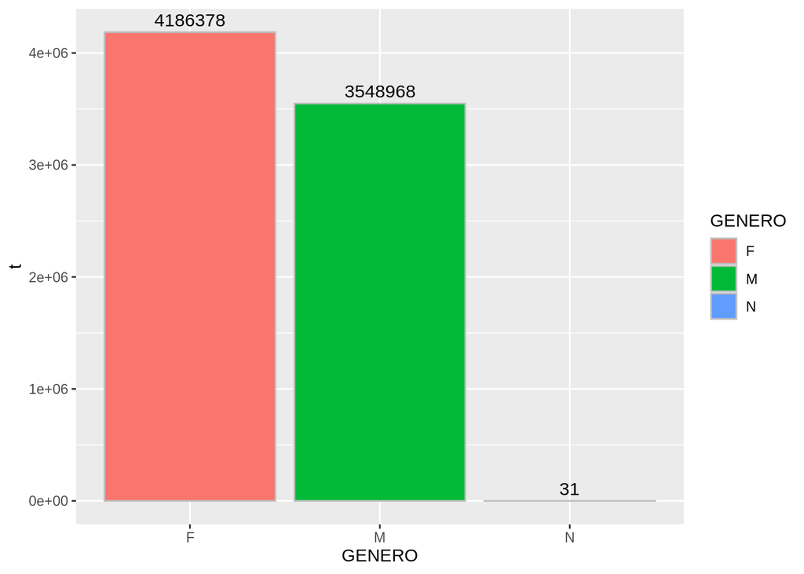

```r
ggplot(data1) +
  geom_bar(aes(GENERO,t, fill = GENERO), stat="identity", colour = "grey") +
  geom_text(aes(x= GENERO, y = t, label= t), vjust= -0.5, color="black", size=4)
```

##### [*options(…)*](https://www.rdocumentation.org/packages/base/versions/3.6.2/topics/options) nos permite ver y configurar opciones globales de R.

##### Entre ellas, *scipen*, con la que podemos controlar cuando usar notación cientifica.

##### *scipen*: Los valores positivos sesgan hacia la notación fija y los negativos hacia la notación científica: se preferirá la notación fija a menos que sea más que dígitos scipen más anchos.

##### Por defecto es cero.

```r
# guardo el valor actual
actual <- options("scipen")
# indico que use notación fija a menos que sean mas de 10 digitos:
options(scipen=10)
```

#### Sín notación cientifica y “factor comun” en aes(…)

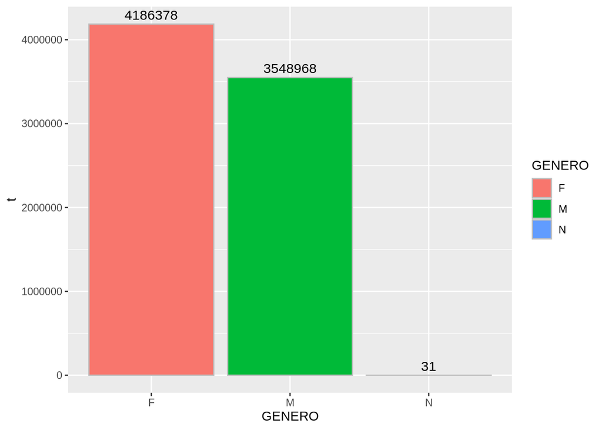

```r
ggplot(data1, aes(GENERO,t, fill = GENERO)) +
  geom_bar(stat="identity", colour = "grey") +
  geom_text(aes(label= t), vjust= -0.5, color="black", size=4)
```

```r
# vuelvo a poner el valor anterior.
options(scipen=actual[[1]])
```

#### Calculamos totales por GENERO y GRUPO_ETARIO

```r
data2 <- vacunas %>%
         mutate(total = (DOSIS_1 + DOSIS_2 + DOSIS_3)) %>%
         select(FECHA_ADMINISTRACION, GENERO, GRUPO_ETARIO, total) %>%
         group_by(GRUPO_ETARIO, GENERO) %>%
         summarise(t = sum(total, na.rm=TRUE))
data2
```

```
## # A tibble: 20 × 3
## # Groups:   GRUPO_ETARIO [8]
##    GRUPO_ETARIO GENERO       t
##    <chr>        <chr>    <dbl>
##  1 30 o menos   F      1210004
##  2 30 o menos   M      1157374
##  3 30 o menos   N           20
##  4 31 a 40      F       683384
##  5 31 a 40      M       630074
##  6 31 a 40      N            9
##  7 41 a 50      F       660298
##  8 41 a 50      M       593206
##  9 41 a 50      N            1
## 10 51 a 60      F       524801
## 11 51 a 60      M       450714
## 12 61 a 70      F       449854
## 13 61 a 70      M       347732
## 14 61 a 70      N            1
## 15 71 a 80      F       385846
## 16 71 a 80      M       248425
## 17 81 a 90      F       218723
## 18 81 a 90      M       105781
## 19 91 o mas     F        53468
## 20 91 o mas     M        15662
```

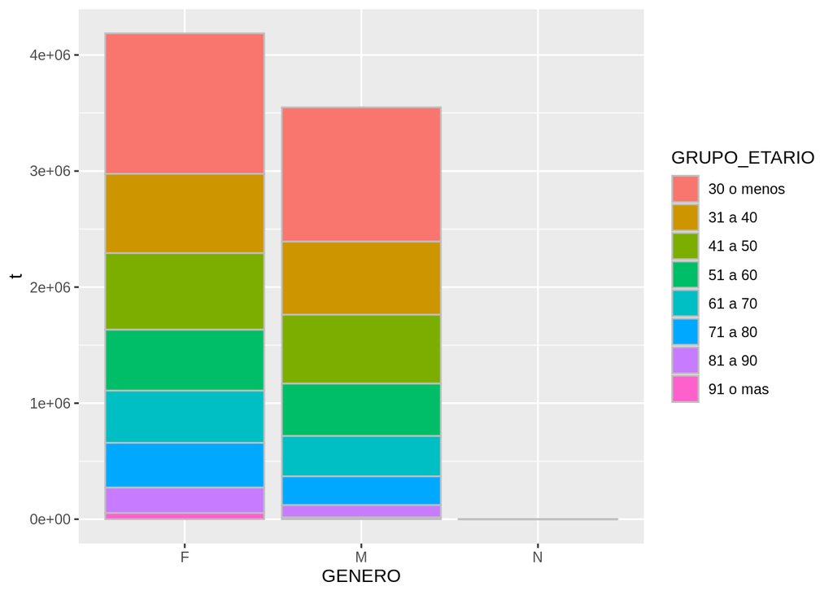

```r
ggplot(data2, aes(GENERO,t, fill=GRUPO_ETARIO)) +
  geom_bar(stat="identity", colour = "grey")
```

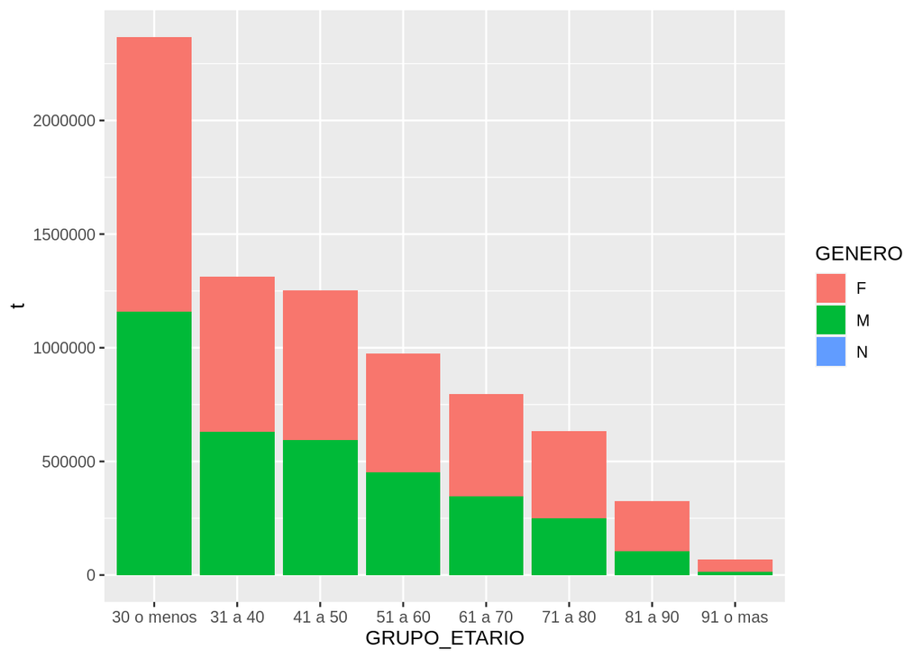

```r
ggplot(data2, aes(GRUPO_ETARIO, t, fill=GENERO)) +
  geom_bar(stat="identity")
```

#### Ahora agrupo primero por GENERO y luego por GRUPO_ETARIO

##### Ver que *data2* y *data3* son iguales salvo el orden de las columnas y las filas

```r
data3 <- vacunas %>%
         mutate(total = (DOSIS_1 + DOSIS_2 + DOSIS_3)) %>%
         select(FECHA_ADMINISTRACION, GENERO, GRUPO_ETARIO, total) %>%
         group_by(GENERO, GRUPO_ETARIO) %>% summarise(t = sum(total, na.rm=TRUE))
data1 %>% tally()
```

```
## # A tibble: 1 × 1
##       n
##   <int>
## 1     3
```

```r
data2 %>% tally()
```

```
## # A tibble: 8 × 2
##   GRUPO_ETARIO     n
##   <chr>        <int>
## 1 30 o menos       3
## 2 31 a 40          3
## 3 41 a 50          3
## 4 51 a 60          2
## 5 61 a 70          3
## 6 71 a 80          2
## 7 81 a 90          2
## 8 91 o mas         2
```

```r
data3 %>% tally()
```

```
## # A tibble: 3 × 2
##   GENERO     n
##   <chr>  <int>
## 1 F          8
## 2 M          8
## 3 N          4
```

#### Los gráficos con data3 ¿Son iguales a los de data2?

##### ¡ probar !

#### Otro paso para ‘acomodar’ los datos:

#### Las “variables” DOSIS_1, DOSIS_2, DOSIS_3, es mejor verlas como tres valores de una nueva variable, implícita en el set de datos, que podemos llamar DOSIS.

#### [*tidyr*](https://tidyr.tidyverse.org/)

#### [*tidyr::pivot_longer()*](https://tidyr.tidyverse.org/reference/pivot_longer.html)

```r
# install.packages("tidyr")
library(tidyr)

vacunas %>% select(GRUPO_ETARIO, GENERO, DOSIS_1, DOSIS_2, DOSIS_3)
```

```
## # A tibble: 35,384 × 5
##    GRUPO_ETARIO GENERO DOSIS_1 DOSIS_2 DOSIS_3
##    <chr>        <chr>    <dbl>   <dbl>   <dbl>
##  1 61 a 70      M          239       2       0
##  2 61 a 70      M           13       0       0
##  3 71 a 80      F           28       0       0
##  4 71 a 80      M            5       0       0
##  5 71 a 80      M           31       0       0
##  6 81 a 90      F            2       0       0
##  7 81 a 90      M            1       0       0
##  8 81 a 90      M            2       0       0
##  9 30 o menos   F           16      41       0
## 10 30 o menos   F           67     146       0
## # … with 35,374 more rows
```

```r
vacunas %>%
  pivot_longer(cols = c(DOSIS_1, DOSIS_2, DOSIS_3), names_to = "DOSIS", values_to = "aplicadas") %>%
  select(FECHA_ADMINISTRACION, GENERO, GRUPO_ETARIO, DOSIS, aplicadas)
```

```
## # A tibble: 106,152 × 5
##    FECHA_ADMINISTRACION GENERO GRUPO_ETARIO DOSIS   aplicadas
##    <chr>                <chr>  <chr>        <chr>       <dbl>
##  1 03FEB2021:00:00:00   M      61 a 70      DOSIS_1       239
##  2 03FEB2021:00:00:00   M      61 a 70      DOSIS_2         2
##  3 03FEB2021:00:00:00   M      61 a 70      DOSIS_3         0
##  4 03FEB2021:00:00:00   M      61 a 70      DOSIS_1        13
##  5 03FEB2021:00:00:00   M      61 a 70      DOSIS_2         0
##  6 03FEB2021:00:00:00   M      61 a 70      DOSIS_3         0
##  7 03FEB2021:00:00:00   F      71 a 80      DOSIS_1        28
##  8 03FEB2021:00:00:00   F      71 a 80      DOSIS_2         0
##  9 03FEB2021:00:00:00   F      71 a 80      DOSIS_3         0
## 10 03FEB2021:00:00:00   M      71 a 80      DOSIS_1         5
## # … with 106,142 more rows
```

```r
data4 <- vacunas %>%
         pivot_longer(cols = c(DOSIS_1, DOSIS_2, DOSIS_3), names_to = "DOSIS", values_to = "aplicadas") %>%
         select(FECHA_ADMINISTRACION, GENERO, GRUPO_ETARIO, DOSIS, aplicadas) %>%
         group_by(GRUPO_ETARIO, GENERO, DOSIS) %>% summarise(t = sum(aplicadas))
data4
```

```
## # A tibble: 60 × 4
## # Groups:   GRUPO_ETARIO, GENERO [20]
##    GRUPO_ETARIO GENERO DOSIS        t
##    <chr>        <chr>  <chr>    <dbl>
##  1 30 o menos   F      DOSIS_1 499192
##  2 30 o menos   F      DOSIS_2 465747
##  3 30 o menos   F      DOSIS_3 245065
##  4 30 o menos   M      DOSIS_1 490795
##  5 30 o menos   M      DOSIS_2 448848
##  6 30 o menos   M      DOSIS_3 217731
##  7 30 o menos   N      DOSIS_1      9
##  8 30 o menos   N      DOSIS_2      7
##  9 30 o menos   N      DOSIS_3      4
## 10 31 a 40      F      DOSIS_1 251175
## # … with 50 more rows
```

##### **facet_wrap**

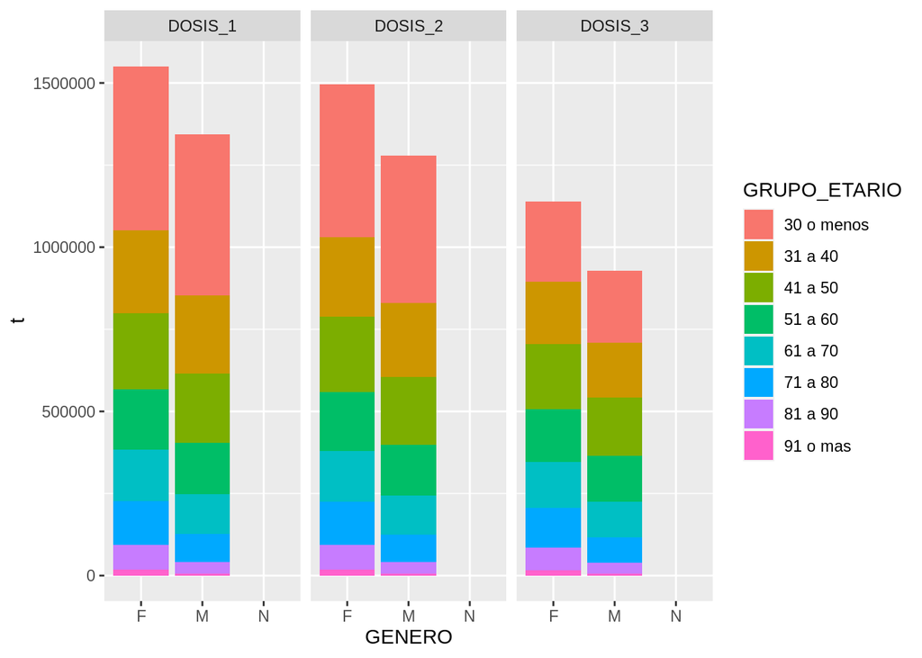

```r
data4 %>% ggplot(aes(x = GENERO, y = t, fill = GRUPO_ETARIO)) +
    geom_bar(stat="identity") +
    facet_wrap(~ DOSIS)
```

#### Un poco más de *ggplot*

##### *ggplot*, *aes*, *stat*, *position*, *facet*

```r
dfa <- data.frame(v1 = c("a","b","c","a"), v2 = c(2,5,2,1))
dfa
```

```
##   v1 v2
## 1  a  2
## 2  b  5
## 3  c  2
## 4  a  1
```

#### *geom_bar* por defecto solo requiere *aes(x)* y hace un counteo. *stat =“count”*

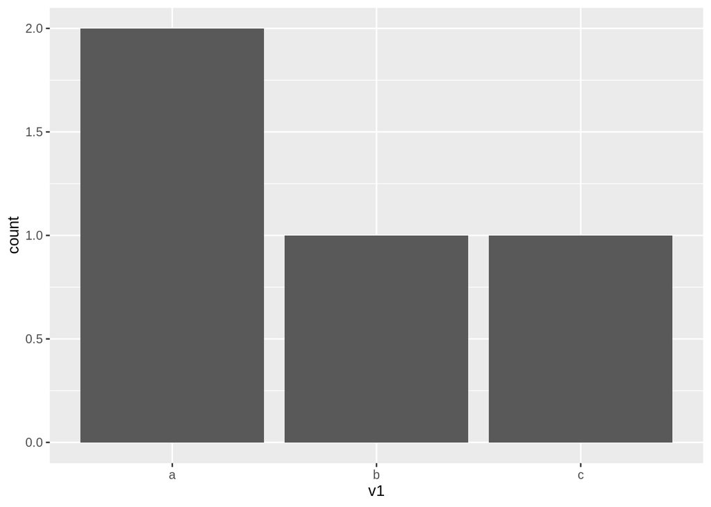

```r
ggplot(dfa, aes(v1)) +
  geom_bar()
```

##### El mismo gráfico con los valores por defecto explicitados:

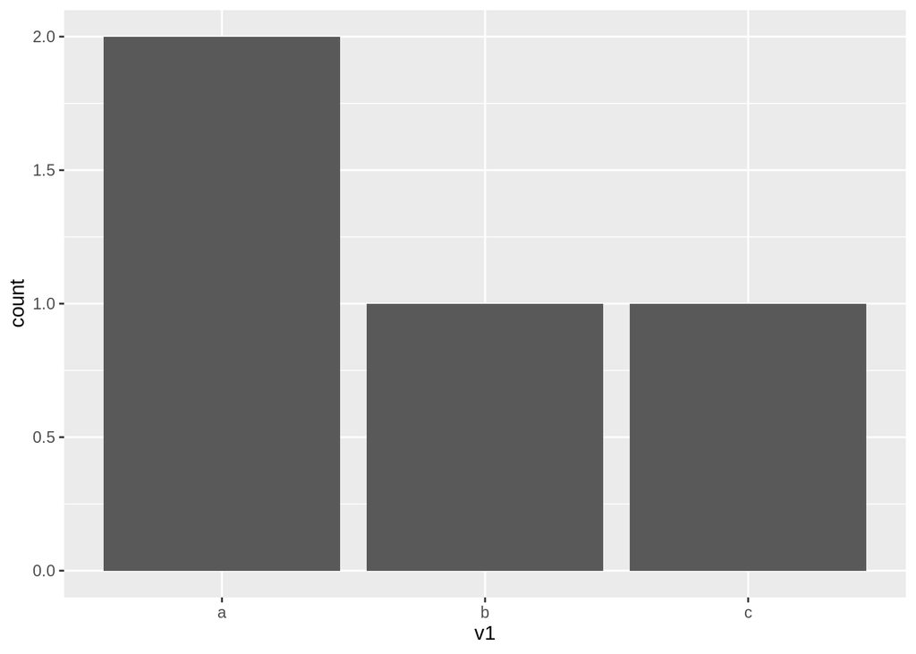

```r
ggplot(dfa, aes(v1)) +
  geom_bar(stat="count")
```

#### *geom_bar* con *stat = identity* agrupa por *x* ademas suma todos los casos

#### requiere *aes(x, y)*

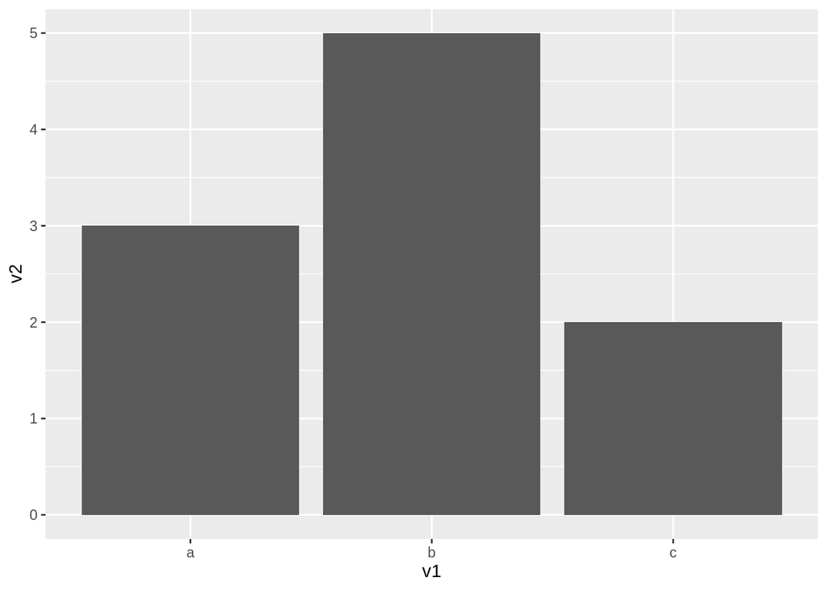

```r
ggplot(dfa, aes(v1, v2)) +
  geom_bar(stat="identity")
```

#### por defecto *position* es *“stack”*

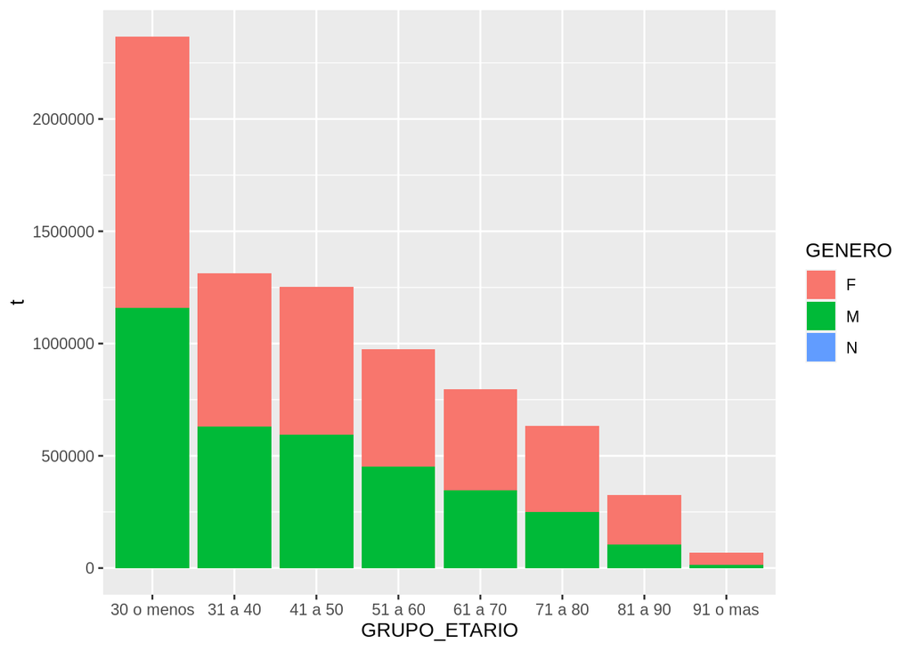

```r
ggplot(data2, aes(GRUPO_ETARIO, t, fill=GENERO)) +
  geom_bar(stat="identity", position = "stack")
```

#### Con *position* = *“dodge”*

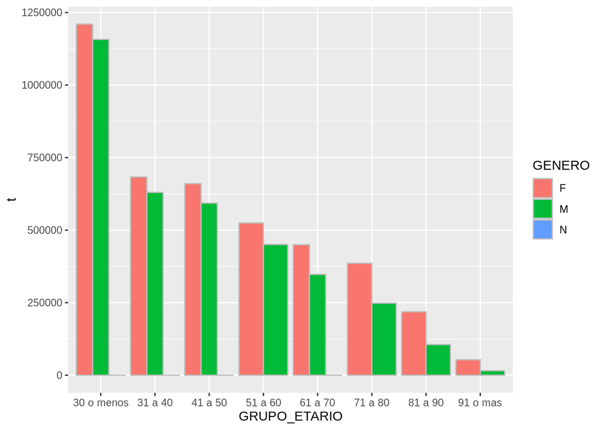

```r
ggplot(data2, aes(GRUPO_ETARIO, t, fill=GENERO)) +
  geom_bar(stat="identity", position = "dodge", colour = "grey")
```

```r
# el el grafico de arriba, algunos tienen tres columnas otros dos (donde no hay casos GENERO = N)
```

#### preserve (anchos de columna)

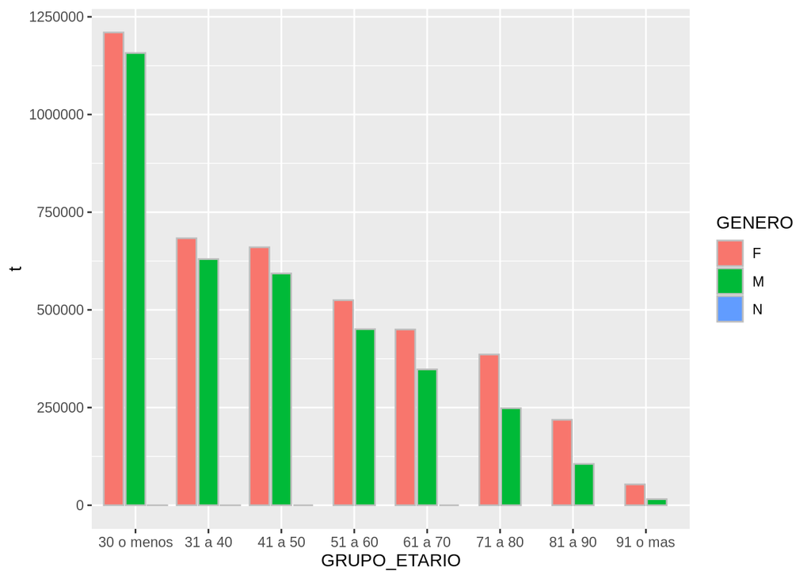

```r
ggplot(data2, aes(GRUPO_ETARIO, t, fill=GENERO)) +
  geom_bar(stat="identity", position = position_dodge2(preserve = "single"), colour = "grey")
```

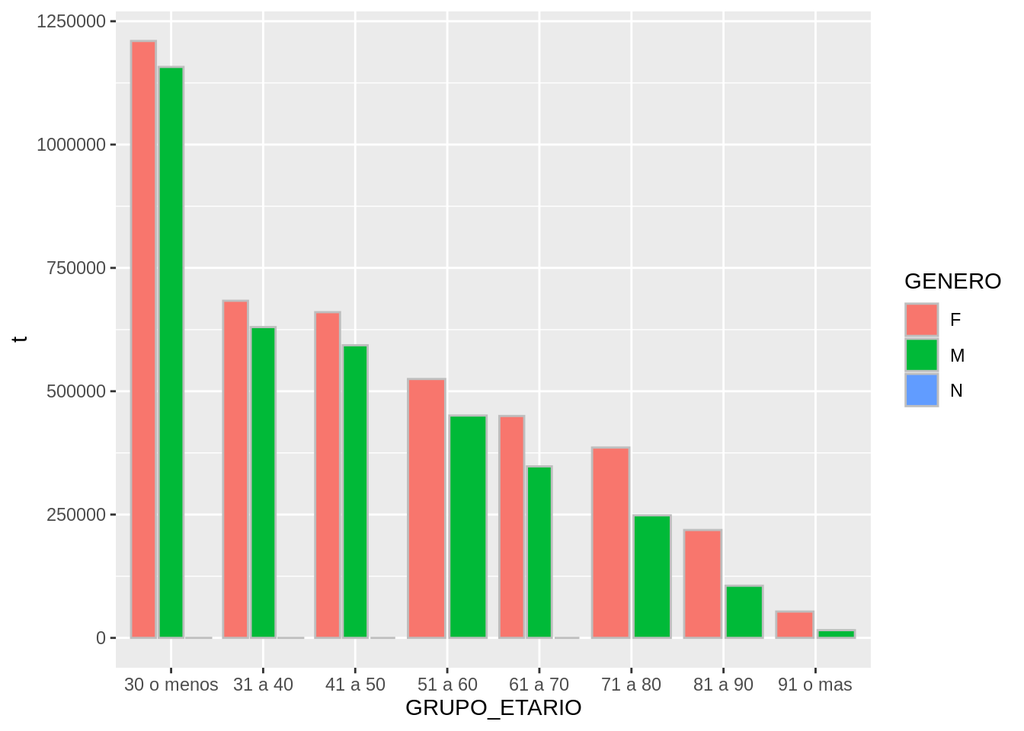

```r
ggplot(data2, aes(GRUPO_ETARIO, t, fill=GENERO)) +
  geom_bar(stat="identity", position = position_dodge2(preserve = "total"), colour = "grey")
```

#### Con *position* = *“fill”*

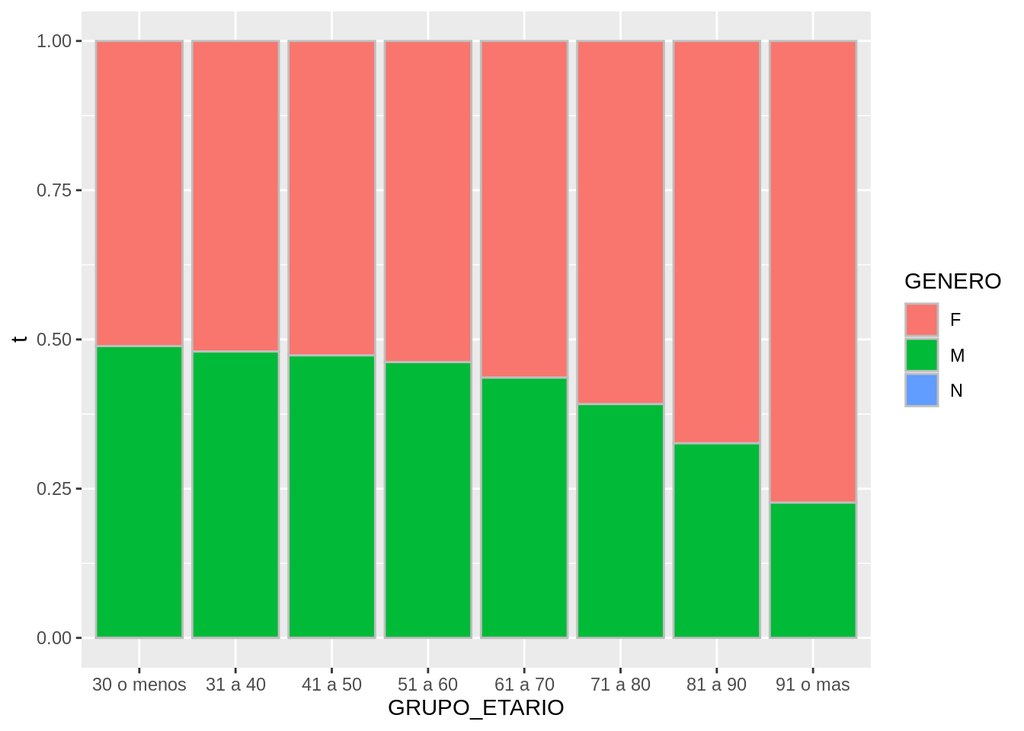

```r
ggplot(data2, aes(GRUPO_ETARIO, t, fill=GENERO)) +
  geom_bar(stat="identity", position = "fill", colour = "grey")
```

### Ejercicios

### Bibliografia:

#### [R para Ciencia de Datos - Cap 5 Transformación de datos](https://es.r4ds.hadley.nz/transform.html#transform)

#### [Cheat Sheet *dplyr*](https://dplyr.tidyverse.org/index.html#cheat-sheet)

clase02.R